```r
library(ggplot2)
library(corrplot)
path="D:/MAAL 2/sem 5/DataAnalytics/Project/Anatomy-of-a-Popular-Song/"
```

```r
path1="norm-age-waf-data/us_waf.csv"
path2="norm-age-waf-data/pa_waf.csv"
path3="norm-age-waf-data/ph_waf.csv"
path4="norm-age-waf-data/de_waf.csv"
path5="norm-age-waf-data/es_waf.csv"
path6="norm-age-waf-data/fr_waf.csv"
```

```r
us = read.csv(paste0(path,path1))
pa = read.csv(paste0(path,path2))
ph = read.csv(paste0(path,path3))
de = read.csv(paste0(path,path4))
es = read.csv(paste0(path,path5))
fr = read.csv(paste0(path,path6))
```

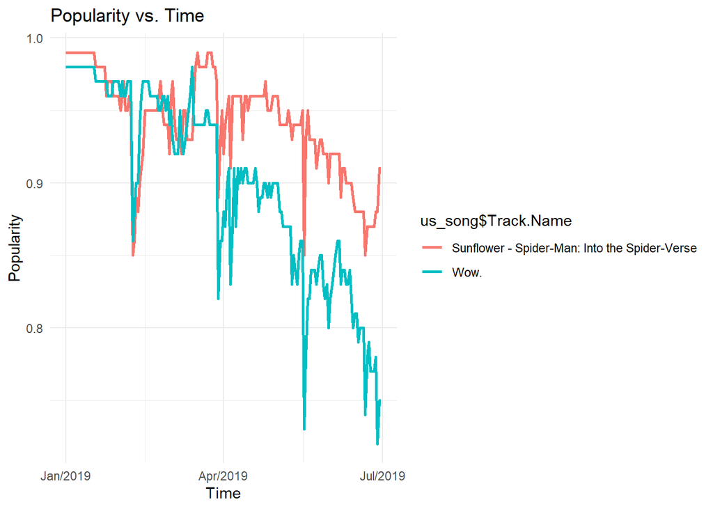

```r
us$Date=paste0(us$Year,'-',us$Month,'-',us$Day)
us$Date=as.Date(us$Date)
us_song=us[us$Track.Name %in% c("Sunflower - Spider-Man: Into the Spider-Verse", "Wow.") ,]
us_song1=us[us$Track.Name %in% c("Sunflower - Spider-Man: Into the Spider-Verse", "7 rings") ,]
min <- as.Date("2019-1-1")
max <- as.Date("2019-6-30")
ggplot(us_song, aes(x = us_song$Date, y = (100-us_song$Position)/100)) +
  geom_line(aes(color = us_song$Track.Name), size = 1) +

  theme_minimal()+scale_x_date(date_labels = "%b/%Y",limits = c(min, max))+xlab("Time") +
  ylab("Popularity") +
  ggtitle("Popularity vs. Time")
```

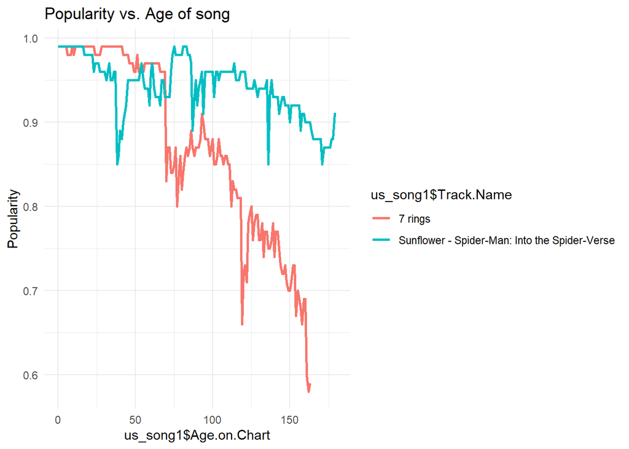

```r
ggplot(us_song1, aes(x = us_song1$Age.on.Chart, y = (100-us_song1$Position)/100)) +
  geom_line(aes(color = us_song1$Track.Name), size = 1) +

  theme_minimal()+
  ylab("Popularity") +
  ggtitle("Popularity vs. Age of song")
```

Graph 1 shows that the popularity of a song goes down with time(Example taken of 2 songs). However in graph 1 we notice that on 8th febrauary 2019 both the songs popularity goes down . Why is this?

One 8th february 2019 Ariana Grande relased an album “Thank you next which contisted of 10 songs . hence on this day popularity of other songs went down”.

From the next graph between sunflower and 7 rings we can see that the Ariana Grande’s Album dint do so well .So it decreased ,where as sunflower did well over time.

SEEING THE VALUE SPREAD OF DIFFRENT FEATURES OF POPULAR SONGS IN DIFFRENT COUNTRIES

```r
x=data.frame(us$danceability, pa$danceability,ph$danceability,de$danceability,es$danceability,fr$danceability)
x1=data.frame(us$acousticness, pa$acousticness,ph$acousticness,de$acousticness,es$acousticness,fr$acousticness)

x2=data.frame(us$energy, pa$energy,ph$energy,de$energy,es$energy,fr$energy)

x3=data.frame(us$speechiness,pa$speechiness,ph$speechiness,de$speechiness,es$speechiness,fr$speechiness)

x4=data.frame(us$liveness,pa$liveness,ph$liveness,de$liveness,es$liveness,fr$liveness)

x5=data.frame(us$norm_tempo,pa$norm_tempo,ph$norm_tempo,de$norm_tempo,es$norm_tempo,fr$norm_tempo)
```

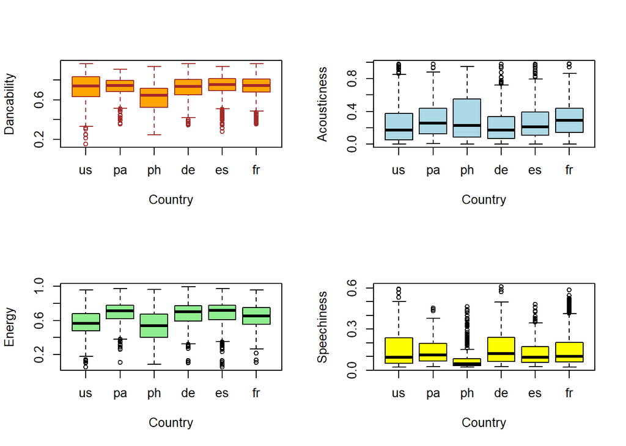

```r
par(mfrow=c(2,2))
boxplot(x,names = c("us", "pa", "ph","de","es","fr"),
col = c("orange"),
border = "brown",xlab="Country",
ylab="Dancability")

boxplot(x1,names = c("us", "pa", "ph","de","es","fr"),col = c("light blue"),xlab="Country",
ylab="Acousticness")

boxplot(x2,names = c("us", "pa", "ph","de","es","fr"),col = c("light green"),xlab="Country",
ylab="Energy")

boxplot(x3,names = c("us", "pa", "ph","de","es","fr"),col = c("yellow"),xlab="Country",
ylab="Speechiness")
```

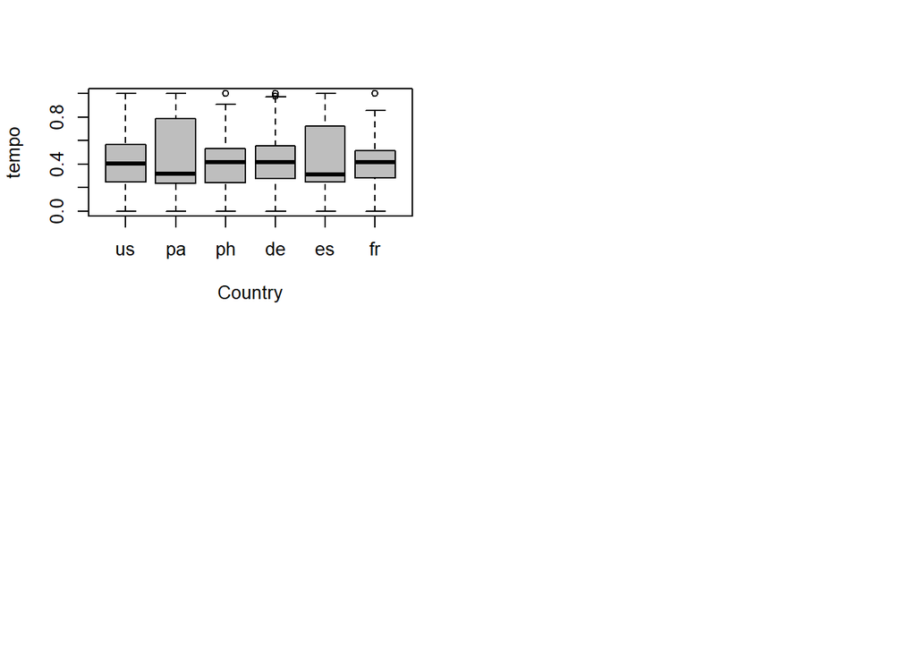

```r
boxplot(x5,names = c("us", "pa", "ph","de","es","fr"),col = c("grey"),xlab="Country",
ylab="tempo")
```

From the above graphs we can conclude that popular songs have: 1) High dancability 2) Low acoustics 3) Medium energy (Slightly on higher side) 4) Low speechiness 5) Medium Tempo (Slightly on lower side)

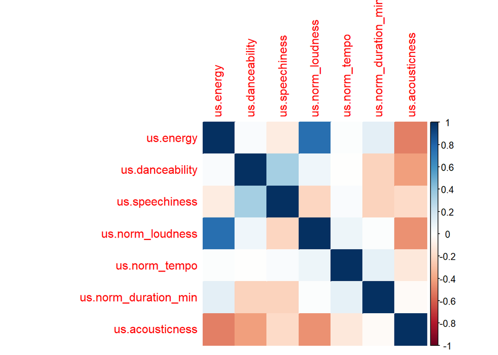

```r
us_cor=data.frame(us$energy,us$danceability,us$speechiness,us$norm_loudness,us$norm_tempo,us$norm_duration_min,us$acousticness)
par(mfrow=c(1,1))
m=cor(us_cor)

corrplot(m, method="color")
```

With in a country the few attributes have correlation 1) Energy and Loudness have a positive correlation as expected 2) Energy and acousticness have negative correlation

[figure not shown]

```r
par(mfrow=c(1,2))
energy=data.frame(us$energy[us$Position == 1],pa$energy[pa$Position == 1],ph$energy[ph$Position == 1],es$energy[es$Position == 1],de$energy[de$Position == 1],fr$energy[fr$Position == 1])
m1=cor(energy)
rownames(m1) <- c("US", "PA","PH","ES","DE","FR")
colnames(m1) <- c("US", "PA","PH","ES","DE","FR")
corrplot(m1, method="shade",title="ENERGY")
sp=data.frame(us$speechiness[us$Position == 1],pa$speechiness[pa$Position == 1],ph$speechiness[ph$Position == 1],es$speechiness[es$Position == 1],de$speechiness[de$Position == 1],fr$speechiness[fr$Position == 1])
m2=cor(sp)
rownames(m2) <- c("US", "PA","PH","ES","DE","FR")
colnames(m2) <- c("US", "PA","PH","ES","DE","FR")
corrplot(m2, method="shade",title="SPEECHINESS")
```

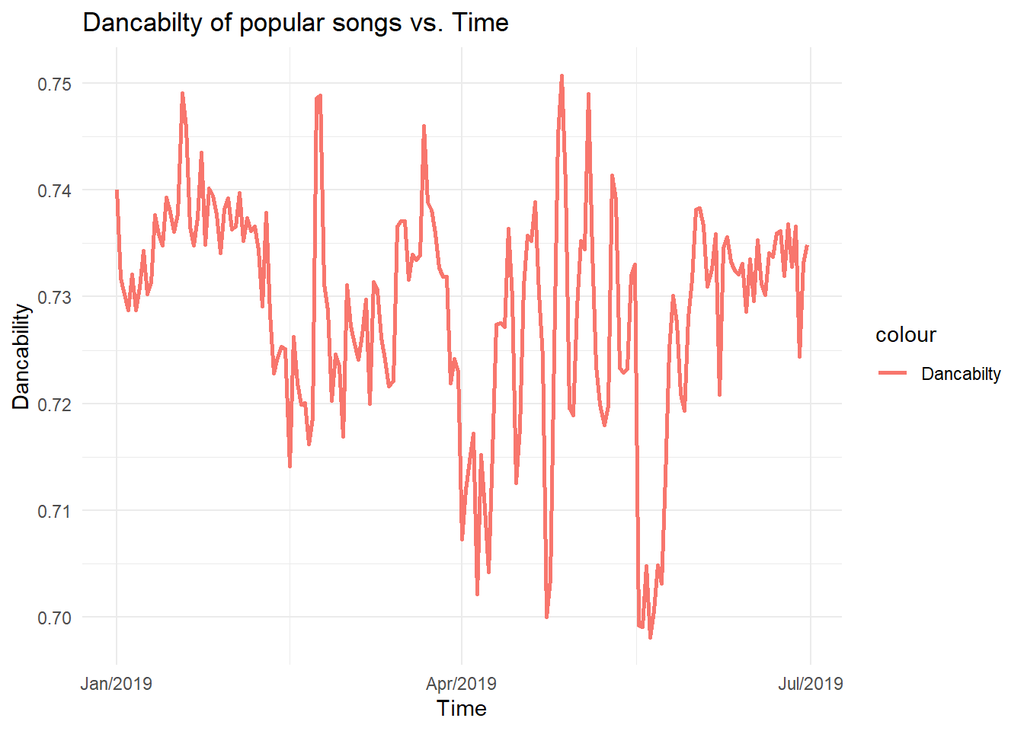

```r
par(mfrow=c(1,2))
d<-data.frame(us$Date,us$danceability)
ag=aggregate(us$danceability ~ us$Date, d, mean)


min <- as.Date("2019-1-1")
max <- as.Date("2019-6-30")
ggplot(ag, aes(x = ag$`us$Date`, y =ag$`us$danceability`) )+
  geom_line(aes(color = "Dancabilty"), size = 1) +

  theme_minimal()+scale_x_date(date_labels = "%b/%Y",limits = c(min, max))+xlab("Time") +
  ylab("Dancability") +
  ggtitle("Dancabilty of popular songs vs. Time")
```

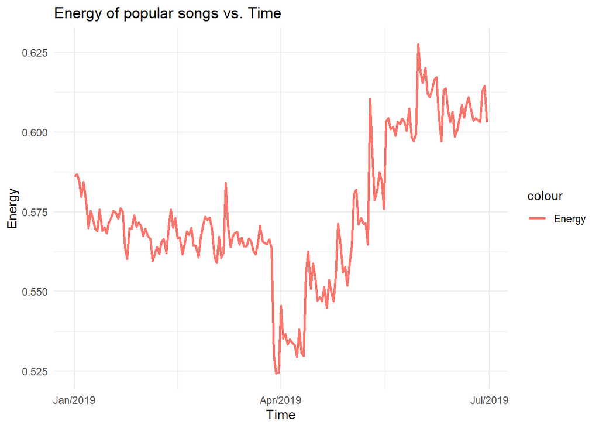

```r
d<-data.frame(us$Date,us$energy)
ag=aggregate(us$energy ~ us$Date, d, mean)
ggplot(ag, aes(x = ag$`us$Date`, y =ag$`us$energy`) )+
  geom_line(aes(color = "Energy"), size = 1) +

  theme_minimal()+scale_x_date(date_labels = "%b/%Y",limits = c(min, max))+xlab("Time") +
  ylab("Energy") +
  ggtitle("Energy of popular songs vs. Time")
```

```r
d<-data.frame(us$Position,us$acousticness)
ag=aggregate(us$acousticness ~ us$Position, d, median)
```

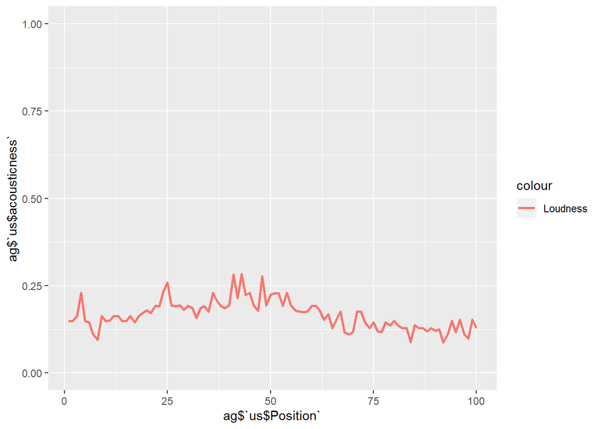

```r
ggplot(ag, aes(x = ag$`us$Position`, y =ag$`us$acousticness`) )+
  geom_line(aes(color = "Loudness"), size = 1) +ylim(0, 1)
```